# In-class 11

INFO 5871-001

Robin Burke

## Imports

```python
import pandas as pd
import numpy as np
import matplotlib.pyplot as plt
import seaborn as sns
import scipy.stats as st
from scipy.special import expit
# Avoids certain warning messages later
from pandas.plotting import register_matplotlib_converters
register_matplotlib_converters()
#from sklearn.linear_model import LinearRegression
#from sklearn.metrics import r2_score
import statsmodels.formula.api as sm
import sqlalchemy as sqla
```

## Set up to use SQLAlchemy

```python
eng = sqla.create_engine('sqlite:///donors_choose.db')
```

### Create SQL query

We want `Date`, `Donation_Amount`, `PFL`, `Metro_Type`, `Project_Cost`, `Status`. This requires a join across three tables: `donations`, `projects`, `schools`. We will also filter donation amounts > 500 and state is Colorado and cost < 6000.

```python
query = 'SELECT donations.Date, \
            donations.Donation_Amount, \
            schools.School_Percentage_Free_Lunch, \
            schools.School_Metro_Type, \
            projects.Project_Cost, \
            projects.Project_Current_Status \
        FROM donations, projects, schools \
        WHERE donations.Donation_Amount > 500 AND \
            donations.Project_ID = projects.Project_ID AND \
            projects.School_ID = schools.School_ID AND \
            schools.School_State = "Colorado" AND \
            projects.Project_Cost < 6000 \
        ORDER BY donations.Date'
dcdf = pd.read_sql_query(query, eng)
dcdf.head()
```

|  | Date | Donation_Amount | School_Percentage_Free_Lunch | School_Metro_Type | Project_Cost | Project_Current_Status |
| --- | --- | --- | --- | --- | --- | --- |
| 0 | 2017-01-01 01:56:16.000000 | 1206.21 | 47.0 | urban | 2561.42 | Fully Funded |
| 1 | 2017-01-04 11:25:25.000000 | 2265.84 | 26.0 | town | 2290.84 | Fully Funded |
| 2 | 2017-01-04 11:25:25.000000 | 512.45 | 36.0 | town | 574.41 | Fully Funded |
| 3 | 2017-01-04 17:05:10.000000 | 700.00 | 7.0 | suburban | 886.27 | Fully Funded |
| 4 | 2017-01-05 15:22:37.000000 | 932.65 | 53.0 | suburban | 1057.65 | Fully Funded |

## Backwards-selection to predict donation amount

Status isn't included. User won't know if something will fund or not when they are deciding what to donate.

Step 1: Full model

```python
model1=sm.ols(formula="Donation_Amount ~ Project_Cost + School_Percentage_Free_Lunch + School_Metro_Type",
              data=dcdf)
reg1 = model1.fit()
```

```python
reg1.summary()
```

OLS Regression Results

| Dep. Variable: | Donation_Amount | R-squared: | 0.408 |
| --- | --- | --- | --- |
| Model: | OLS | Adj. R-squared: | 0.384 |
| Method: | Least Squares | F-statistic: | 16.67 |
| Date: | Mon, 04 Nov 2019 | Prob (F-statistic): | 1.43e-14 |
| Time: | 16:14:35 | Log-Likelihood: | -1104.0 |
| No. Observations: | 152 | AIC: | 2222. |
| Df Residuals: | 145 | BIC: | 2243. |
| Df Model: | 6 |  |  |
| Covariance Type: | nonrobust |  |  |

|  | coef | std err | t | P>\|t\| | [0.025 | 0.975] |
| --- | --- | --- | --- | --- | --- | --- |
| Intercept | 463.6844 | 144.843 | 3.201 | 0.002 | 177.407 | 749.961 |
| School_Metro_Type[T.suburban] | -114.3275 | 135.842 | -0.842 | 0.401 | -382.814 | 154.159 |
| School_Metro_Type[T.town] | 92.3251 | 144.730 | 0.638 | 0.525 | -193.729 | 378.379 |
| School_Metro_Type[T.unknown] | -53.7444 | 178.052 | -0.302 | 0.763 | -405.658 | 298.169 |
| School_Metro_Type[T.urban] | -33.3913 | 134.373 | -0.248 | 0.804 | -298.973 | 232.191 |
| Project_Cost | 0.3541 | 0.036 | 9.799 | 0.000 | 0.283 | 0.425 |
| School_Percentage_Free_Lunch | -0.8856 | 1.246 | -0.711 | 0.478 | -3.348 | 1.576 |

| Omnibus: | 39.100 | Durbin-Watson: | 1.783 |
| --- | --- | --- | --- |
| Prob(Omnibus): | 0.000 | Jarque-Bera (JB): | 89.836 |
| Skew: | 1.083 | Prob(JB): | 3.11e-20 |
| Kurtosis: | 6.081 | Cond. No. | 1.65e+04 |

Warnings:  
[1] Standard Errors assume that the covariance matrix of the errors is correctly specified.  
[2] The condition number is large, 1.65e+04. This might indicate that there are  
strong multicollinearity or other numerical problems.

### Look up the AIC

```python
reg1.aic
```

```
2221.906831006898
```

### Step 2: Remove each variable

- 2a: Drop project cost
- 2b: Drop free lunch
- 2c: Drop metro type

```python
model2a=sm.ols(formula="Donation_Amount ~ School_Percentage_Free_Lunch + School_Metro_Type",
              data=dcdf)
reg2a = model2a.fit()
reg2a.aic
```

```
2297.143565506636
```

```python
model2b=sm.ols(formula="Donation_Amount ~ Project_Cost + School_Metro_Type",
              data=dcdf)
reg2b = model2b.fit()
reg2b.aic
```

```
2220.4356868288714
```

```python
model2c=sm.ols(formula="Donation_Amount ~ Project_Cost + School_Percentage_Free_Lunch",
              data=dcdf)
reg2c = model2c.fit()
reg2c.aic
```

```
2219.401552740727
```

### 2c is the lowest (although not a lot of difference between b and c)

It makes sense that the more improverished school correlate with the metro area.

### Step 3

- 3a: Drop project cost
- 3b: Drop PFL

```python
model3a=sm.ols(formula="Donation_Amount ~ School_Percentage_Free_Lunch",
              data=dcdf)
reg3a = model3a.fit()
reg3a.aic
```

```
2291.653734753365
```

```python
model3b=sm.ols(formula="Donation_Amount ~  Project_Cost",
              data=dcdf)
reg3b = model3b.fit()
reg3b.aic
```

```
2217.643884362867
```

### So we will pretend 2c is our best model

Actually 3b has lower AIC, but it only has one variables, so is less interesting to do our diagnostics.

```python
reg2c.summary()
```

OLS Regression Results

| Dep. Variable: | Donation_Amount | R-squared: | 0.386 |
| --- | --- | --- | --- |
| Model: | OLS | Adj. R-squared: | 0.378 |
| Method: | Least Squares | F-statistic: | 46.93 |
| Date: | Mon, 04 Nov 2019 | Prob (F-statistic): | 1.56e-16 |
| Time: | 16:14:42 | Log-Likelihood: | -1106.7 |
| No. Observations: | 152 | AIC: | 2219. |
| Df Residuals: | 149 | BIC: | 2228. |
| Df Model: | 2 |  |  |
| Covariance Type: | nonrobust |  |  |

|  | coef | std err | t | P>\|t\| | [0.025 | 0.975] |
| --- | --- | --- | --- | --- | --- | --- |
| Intercept | 417.8197 | 82.634 | 5.056 | 0.000 | 254.535 | 581.105 |
| Project_Cost | 0.3487 | 0.036 | 9.688 | 0.000 | 0.278 | 0.420 |
| School_Percentage_Free_Lunch | -0.5633 | 1.155 | -0.488 | 0.627 | -2.846 | 1.719 |

| Omnibus: | 41.680 | Durbin-Watson: | 1.771 |
| --- | --- | --- | --- |
| Prob(Omnibus): | 0.000 | Jarque-Bera (JB): | 95.209 |
| Skew: | 1.160 | Prob(JB): | 2.12e-21 |
| Kurtosis: | 6.106 | Cond. No. | 4.66e+03 |

Warnings:  
[1] Standard Errors assume that the covariance matrix of the errors is correctly specified.  
[2] The condition number is large, 4.66e+03. This might indicate that there are  
strong multicollinearity or other numerical problems.

### Histogram of residuals

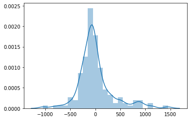

```python
sns.distplot(reg2c.resid)
```

### Look at each project variable

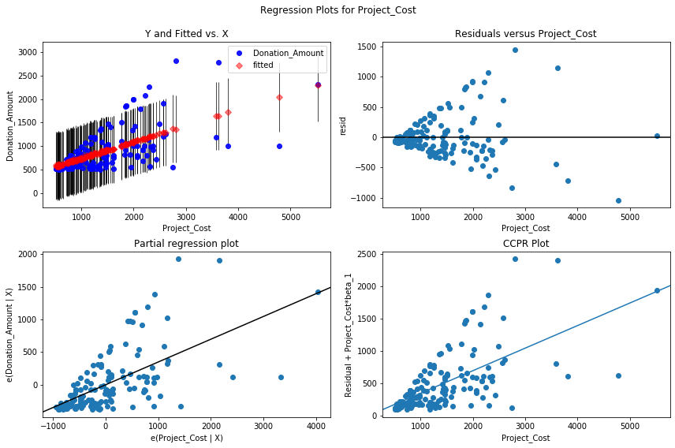

```python
import statsmodels.api as sma

fig = plt.figure(figsize=(12,8))
fig = sma.graphics.plot_regress_exog(reg2c, "Project_Cost", fig=fig)
```

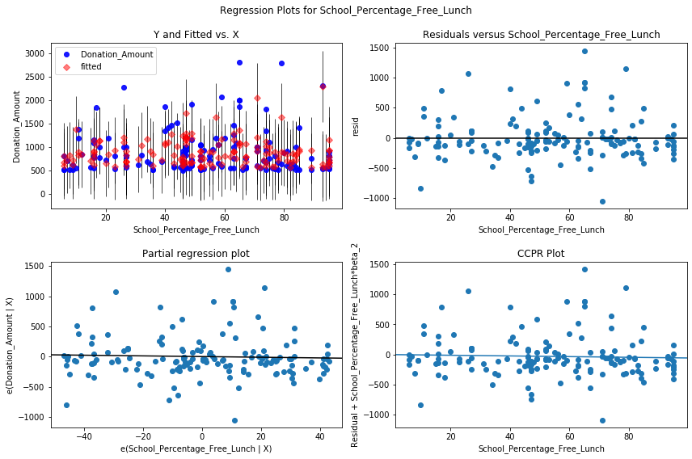

```python
import statsmodels.api as sma

fig = plt.figure(figsize=(12,8))
fig = sma.graphics.plot_regress_exog(reg2c, "School_Percentage_Free_Lunch", fig=fig)
```

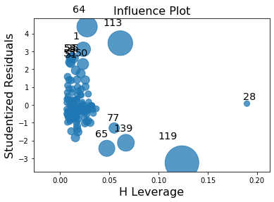

```python
p = sma.graphics.influence_plot(reg2c, criterion="cooks")
```

```python
dcdf.loc[119,:]
```

```
Date                            2017-11-08 13:16:11.000000
Donation_Amount                                       1000
School_Percentage_Free_Lunch                            71
School_Metro_Type                                    urban
Project_Cost                                       4776.54
Project_Current_Status                        Fully Funded
Name: 119, dtype: object
```

## Logistic regression

Predict Expired vs Funded. This is a project property so we don't need the donation information. Write SQL query to select `PFL`, `Metro_Type`, `Cost`, and `Current_Status`.

We will use backward-selection but using p-value instead of AIC. This is quicker, but may sacrifice some prediction accuracy for more explainable models.

```python
query = 'SELECT schools.School_Percentage_Free_Lunch, \
            schools.School_Metro_Type, \
            projects.Project_Cost, \
            projects.Project_Current_Status \
        FROM projects, schools \
        WHERE projects.Project_ID AND \
            projects.School_ID = schools.School_ID'
dcdf2 = pd.read_sql_query(query, eng)
dcdf2.head()
```

|  | School_Percentage_Free_Lunch | School_Metro_Type | Project_Cost | Project_Current_Status |
| --- | --- | --- | --- | --- |
| 0 | 95.0 | suburban | 361.80 | Fully Funded |
| 1 | 77.0 | urban | 175.15 | Fully Funded |
| 2 | 89.0 | urban | 3020.59 | Fully Funded |
| 3 | 69.0 | suburban | 566.19 | Expired |
| 4 | 95.0 | unknown | 339.20 | Fully Funded |

### Use `get_dummies` to set up dummy variables

Built-in `logit` won't do this for us. Rename columns.

```python
dcdf2d = pd.get_dummies(dcdf2, columns=['School_Metro_Type', 'Project_Current_Status'])
dcdf2d.columns = ['PFL', 'Cost', 'MT_Rural', 'MT_Suburban', 'MT_Town', 'MT_Unknown', 'MT_Urban',
                  'Expired', 'Funded', 'Live']
dcdf2d.head()
```

|  | PFL | Cost | MT_Rural | MT_Suburban | MT_Town | MT_Unknown | MT_Urban | Expired | Funded | Live |
| --- | --- | --- | --- | --- | --- | --- | --- | --- | --- | --- |
| 0 | 95.0 | 361.80 | 0 | 1 | 0 | 0 | 0 | 0 | 1 | 0 |
| 1 | 77.0 | 175.15 | 0 | 0 | 0 | 0 | 1 | 0 | 1 | 0 |
| 2 | 89.0 | 3020.59 | 0 | 0 | 0 | 0 | 1 | 0 | 1 | 0 |
| 3 | 69.0 | 566.19 | 0 | 1 | 0 | 0 | 0 | 1 | 0 | 0 |
| 4 | 95.0 | 339.20 | 0 | 0 | 0 | 1 | 0 | 0 | 1 | 0 |

### Run logistic regression

Drop MT_Unknown. It will be the baseline.

```python
model5=sm.logit(formula="Expired ~ Cost + PFL + MT_Rural + MT_Suburban + MT_Town + MT_Urban",
              data=dcdf2d)
reg5 = model5.fit()
```

```
Optimization terminated successfully.
         Current function value: 0.505844
         Iterations 6
```

```python
reg5.summary()
```

Logit Regression Results

| Dep. Variable: | Expired | No. Observations: | 661429 |
| --- | --- | --- | --- |
| Model: | Logit | Df Residuals: | 661422 |
| Method: | MLE | Df Model: | 6 |
| Date: | Mon, 04 Nov 2019 | Pseudo R-squ.: | 0.03253 |
| Time: | 16:15:00 | Log-Likelihood: | -3.3458e+05 |
| converged: | True | LL-Null: | -3.4583e+05 |
| Covariance Type: | nonrobust | LLR p-value: | 0.000 |

|  | coef | std err | z | P>\|z\| | [0.025 | 0.975] |
| --- | --- | --- | --- | --- | --- | --- |
| Intercept | -1.5042 | 0.014 | -109.703 | 0.000 | -1.531 | -1.477 |
| Cost | 0.0005 | 4.3e-06 | 125.329 | 0.000 | 0.001 | 0.001 |
| PFL | -0.0018 | 0.000 | -13.851 | 0.000 | -0.002 | -0.002 |
| MT_Rural | 0.1023 | 0.014 | 7.379 | 0.000 | 0.075 | 0.130 |
| MT_Suburban | -0.0018 | 0.012 | -0.156 | 0.876 | -0.025 | 0.021 |
| MT_Town | 0.1490 | 0.017 | 8.785 | 0.000 | 0.116 | 0.182 |
| MT_Urban | -0.2295 | 0.012 | -19.958 | 0.000 | -0.252 | -0.207 |

### Get the AIC

```python
reg5.aic
```

```
669173.4653713455
```

### Drop `MT_Rural` and `MT_Town`

Question what does this do the baseline case?

```python
# What is the effect of
model6a =sm.logit(formula="Expired ~ Cost + PFL + MT_Suburban + MT_Urban",
              data=dcdf2d)
reg6a = model6a.fit()
```

```
Optimization terminated successfully.
         Current function value: 0.505913
         Iterations 6
```

```python
reg6a.aic
```

```
669260.8171417982
```

```python
reg6a.summary()
```

Logit Regression Results

| Dep. Variable: | Expired | No. Observations: | 661429 |
| --- | --- | --- | --- |
| Model: | Logit | Df Residuals: | 661424 |
| Method: | MLE | Df Model: | 4 |
| Date: | Mon, 04 Nov 2019 | Pseudo R-squ.: | 0.03239 |
| Time: | 16:15:10 | Log-Likelihood: | -3.3463e+05 |
| converged: | True | LL-Null: | -3.4583e+05 |
| Covariance Type: | nonrobust | LLR p-value: | 0.000 |

|  | coef | std err | z | P>\|z\| | [0.025 | 0.975] |
| --- | --- | --- | --- | --- | --- | --- |
| Intercept | -1.4250 | 0.010 | -136.015 | 0.000 | -1.446 | -1.404 |
| Cost | 0.0005 | 4.3e-06 | 125.308 | 0.000 | 0.001 | 0.001 |
| PFL | -0.0018 | 0.000 | -14.216 | 0.000 | -0.002 | -0.002 |
| MT_Suburban | -0.0784 | 0.008 | -9.624 | 0.000 | -0.094 | -0.062 |
| MT_Urban | -0.3054 | 0.008 | -39.052 | 0.000 | -0.321 | -0.290 |

We will work with this, but note how low the (Pseudo) $R^2$ is. Not a great model.

### What types of projects are more likely to get funded?

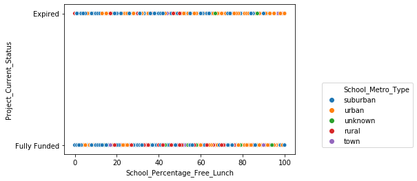

```python
ax = sns.scatterplot(data=dcdf2.query('Project_Current_Status != "Live"'),
                x = 'School_Percentage_Free_Lunch', y='Project_Current_Status',
                hue='School_Metro_Type')
plt.legend(bbox_to_anchor=(1.1, 0.5), bbox_transform=ax.transAxes)
```

### Write a function to compute predictions using the model

```python
def prob_val(pfl, cost, metro_coef):
    val = reg6a.params['Intercept'] + reg6a.params['Cost']*3000 + reg6a.params['PFL']*pfl + metro_coef
    return expit(val)
```

### Compute probabilities for different PFL values

Urban, Suburban, Other

```python
pfl_values = [0, 20, 40, 60, 80, 100]
urb = [prob_val(pfl, 3000, reg6a.params['MT_Urban']) for pfl in pfl_values]
sub = [prob_val(pfl, 3000, reg6a.params['MT_Suburban']) for pfl in pfl_values]
other = [prob_val(pfl, 3000, 0) for pfl in pfl_values]
```

### Create a combined scatterplot with the prediction curves

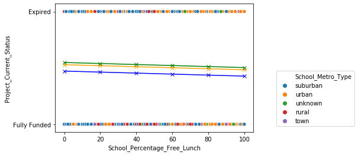

```python
ax = sns.scatterplot(data=dcdf2.query('Project_Current_Status != "Live"'),
                x = 'School_Percentage_Free_Lunch', y='Project_Current_Status',
                hue='School_Metro_Type')
plt.plot(pfl_values, urb, 'bx-')
plt.plot(pfl_values, sub, 'x-', color='orange')
plt.plot(pfl_values, other, 'gx-')
plt.legend(bbox_to_anchor=(1.1, 0.5), bbox_transform=ax.transAxes)
```

Note that Other and Suburban are almost identical.

### Create a combined plot with different project costs

```python
c100 = [prob_val(pfl, 100, reg6a.params['MT_Urban']) for pfl in pfl_values]
c500 = [prob_val(pfl, 500, reg6a.params['MT_Urban']) for pfl in pfl_values]
c1k = [prob_val(pfl, 1000, reg6a.params['MT_Urban']) for pfl in pfl_values]
c2k = [prob_val(pfl, 2000, reg6a.params['MT_Urban']) for pfl in pfl_values]
```

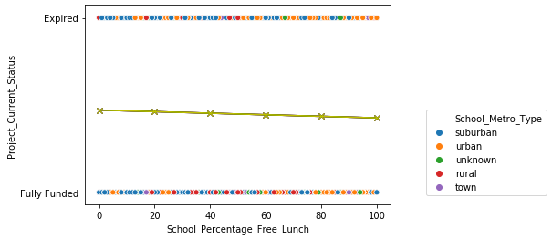

```python
ax = sns.scatterplot(data=dcdf2.query('Project_Current_Status != "Live"'),
                x = 'School_Percentage_Free_Lunch', y='Project_Current_Status',
                hue='School_Metro_Type')
plt.plot(pfl_values, c100, 'bx-')
plt.plot(pfl_values, c500, 'rx-')
plt.plot(pfl_values, c1k, 'gx-')
plt.plot(pfl_values, c2k, 'yx-')
plt.legend(bbox_to_anchor=(1.1, 0.5), bbox_transform=ax.transAxes)
```

We will also combine Other and Suburban because there is little difference there. Only Urban appears in the equation.

```python
dcdf3 = dcdf2d.copy()
model7 =sm.logit(formula="Expired ~ PFL + MT_Urban",
              data=dcdf3)
reg7 = model7.fit()
```

```
Optimization terminated successfully.
         Current function value: 0.521173
         Iterations 5
```

```python
reg7.summary()
```

Logit Regression Results

| Dep. Variable: | Expired | No. Observations: | 661429 |
| --- | --- | --- | --- |
| Model: | Logit | Df Residuals: | 661426 |
| Method: | MLE | Df Model: | 2 |
| Date: | Mon, 04 Nov 2019 | Pseudo R-squ.: | 0.003207 |
| Time: | 16:21:34 | Log-Likelihood: | -3.4472e+05 |
| converged: | True | LL-Null: | -3.4583e+05 |
| Covariance Type: | nonrobust | LLR p-value: | 0.000 |

|  | coef | std err | z | P>\|z\| | [0.025 | 0.975] |
| --- | --- | --- | --- | --- | --- | --- |
| Intercept | -1.0321 | 0.008 | -123.600 | 0.000 | -1.048 | -1.016 |
| PFL | -0.0023 | 0.000 | -18.243 | 0.000 | -0.003 | -0.002 |
| MT_Urban | -0.2293 | 0.006 | -36.480 | 0.000 | -0.242 | -0.217 |

```python
reg7.aic
```

```
689443.8342253466
```

### Follow above pattern to plot with the curves

```python
def prob_val2(pfl, metro_coef):
    val = reg7.params['Intercept'] + reg6a.params['PFL']*pfl + metro_coef
    return expit(val)
```

```python
metro = [prob_val2(pfl, reg7.params['MT_Urban']) for pfl in pfl_values]
other = [prob_val2(pfl, 0) for pfl in pfl_values]
```

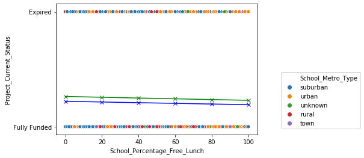

```python
ax = sns.scatterplot(data=dcdf2.query('Project_Current_Status != "Live"'),
                x = 'School_Percentage_Free_Lunch', y='Project_Current_Status',
                hue='School_Metro_Type')
plt.plot(pfl_values, metro, 'bx-')
plt.plot(pfl_values, other, 'gx-')

plt.legend(bbox_to_anchor=(1.1, 0.5), bbox_transform=ax.transAxes)
```